# Predicting Tennis Match Outcomes: A Data-Driven Approach to the Game

Team: SNM Analytics

2023-05-02

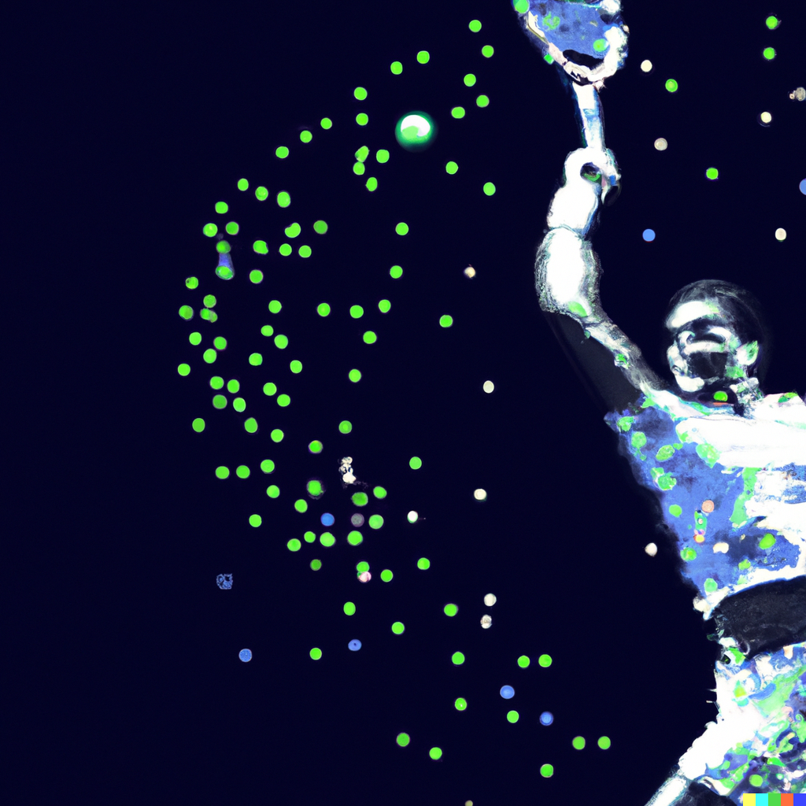

# Chapter 1: Introduction

## Background to Tennis and the project

Tennis is an international sport that captivates people across the globe. Players from diverse backgrounds showcase distinct playing techniques and strengths. A multitude of factors contribute to the excitement and unpredictability of each match. The ability to predict match outcomes holds significant value for many purposes, including imporving and optimizing payers’ winning strategies by finding features with greater winning potential. This summary paper, “Predicting Tennis Match Outcomes: A Data-Driven Approach to the Game” delves into these aspects with the context of data science and machine learning.

## Project Overview

In this analysis, we will examine the Jeff Sackmann tennis ATP match dataset to determine the availability of match-level statistics over the years. The dataset contains information on tennis matches from 1968 to 2023, with more extensive match statistics available starting from 1991. Our goal is to visualize the availability of match statistics and explore the data to understand its structure and contents.

## Research Question

What are the most important features that influence the outcome of a tennis match, and how accurately can we predict the winner of a match using a machine learning model based on these features?

This question not only focuses on prediction accuracy but also emphasizes the importance of understanding which factors contribute the most to the outcome. By answering this question, you can gain insights into the game and potentially develop strategies for players or coaches to improve performance.

```r
# Initialize an empty data frame
data <- data.frame()

# Loop through the years and read the corresponding atp_matches files
for (year in 1968:2023) {
  file_path <- paste0("data/atp_matches_", year, ".csv")
  if (file.exists(file_path)) {
    temp_data <- read.csv(file_path)
    data <- rbind(data, temp_data)
  }
}
```

```r
str(data)
```

```
## 'data.frame':    189185 obs. of  49 variables:
##  $ tourney_id        : chr  "1968-2029" "1968-2029" "1968-2029" "1968-2029" ...
##  $ tourney_name      : chr  "Dublin" "Dublin" "Dublin" "Dublin" ...
##  $ surface           : chr  "Grass" "Grass" "Grass" "Grass" ...
##  $ draw_size         : int  32 32 32 32 32 32 32 32 32 32 ...
##  $ tourney_level     : chr  "A" "A" "A" "A" ...
##  $ tourney_date      : int  19680708 19680708 19680708 19680708 19680708 19680708 19680708 19680708 19680708 19680708 ...
##  $ match_num         : int  270 271 272 273 274 275 276 277 278 279 ...
##  $ winner_id         : int  112411 126914 209523 100084 100132 207073 109783 109745 201749 209525 ...
##  $ winner_seed       : chr  NA NA NA NA ...
##  $ winner_entry      : chr  "" "" "" "" ...
##  $ winner_name       : chr  "Douglas Smith" "Louis Pretorius" "Cecil Pedlow" "Tom Okker" ...
##  $ winner_hand       : chr  "U" "R" "U" "R" ...
##  $ winner_ht         : int  NA NA NA 178 NA NA 183 179 NA NA ...
##  $ winner_ioc        : chr  "AUS" "RSA" "IRL" "NED" ...
```

[output cut: 35 more lines]

## Dataset Description

Some of the key features in the dataset are:

1. Player details: player names, ages, heights, etc.
2. Match details: tournament name, surface, round, etc.
3. Player rankings: ATP rankings and ranking points.
4. Match statistics: aces, double faults, first serves in, first serve points won, etc.

# Chapter 2: Data Preprocessing/Cleaning & EDA

## Data Preprocessing

### Data Cleaning

This code cleans data and conducts exploratory data analysis on a tennis match statistics dataset. The process starts by transforming a character column (tourney_date) into a Date object and extracting the year component into a new column (year). It then selects a selection of numeric columns from the dataset that contain match statistics and computes the percentage of non-null values every year for each column using the dplyr package’s mean() and across() functions. The resulting summary data is then gathered into a long format for easier charting using the gather() function. This code can help guide further studies and modeling efforts by finding trends and patterns in missing data for each match statistic over time.

```r
# Convert tourney_date character type to a Date object
data$tourney_date <- as.Date(as.character(data$tourney_date), "%Y%m%d")

# Extract year from tourney_date
data$year <- year(data$tourney_date)

# Select the relevant columns (numeric match statistics)
stats_columns <- c("w_ace", "w_df", "w_svpt", "w_1stIn", "w_1stWon", "w_2ndWon", "w_SvGms", "w_bpSaved", "w_bpFaced",
                   "l_ace", "l_df", "l_svpt", "l_1stIn", "l_1stWon", "l_2ndWon", "l_SvGms", "l_bpSaved", "l_bpFaced")


# Calculate the percentage of non-null values per year for each numeric variable
non_null_stats <- data %>%
  group_by(year) %>%
  summarize(across(all_of(stats_columns), ~mean(!is.na(.)) * 100, .names = "pct_non_null_{col}"))

# Gather the data into a long format for easy plotting
non_null_stats_long <- non_null_stats %>%
  gather(key = "variable", value = "pct_non_null", -year)
```

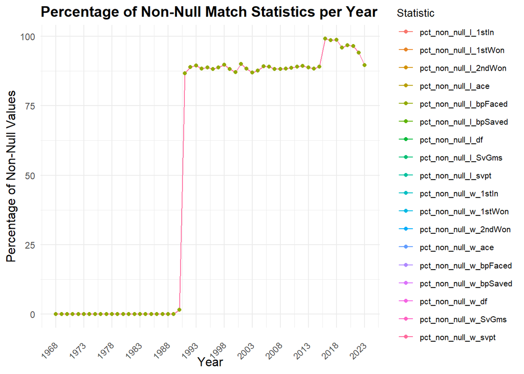

```r
# Plot the percentage of non-null values per year for each numeric variable
ggplot(non_null_stats_long, aes(x = year, y = pct_non_null, color = variable)) +
  geom_line() +
  geom_point() +
  labs(title = "Percentage of Non-Null Match Statistics per Year",
       x = "Year",
       y = "Percentage of Non-Null Values",
       color = "Statistic") +
  theme_minimal() +
  theme(axis.text.x = element_text(angle = 45, vjust = 0.5, hjust = 1),
        plot.title = element_text(size = 14, face = "bold"),
        axis.title.x = element_text(size = 12),
        axis.title.y = element_text(size = 12),
        legend.title = element_text(size = 10),
        legend.text = element_text(size = 8)) +
  scale_x_continuous(breaks = seq(min(non_null_stats_long$year), max(non_null_stats_long$year), by = 5))
```

Since more extensive match level statistics are only available from the year 1991, we concentrate on the ATP match level files from 1991 to 2023.

```r
#Filtering out 1968-1990 data
data <- data %>% filter(year >= 1991)

# Sanity check
str(data)
```

```
## 'data.frame':    103245 obs. of  50 variables:
##  $ tourney_id        : chr  "1991-301" "1991-301" "1991-301" "1991-301" ...
##  $ tourney_name      : chr  "Auckland" "Auckland" "Auckland" "Auckland" ...
##  $ surface           : chr  "Hard" "Hard" "Hard" "Hard" ...
##  $ draw_size         : int  32 32 32 32 32 32 32 32 32 32 ...
##  $ tourney_level     : chr  "A" "A" "A" "A" ...
##  $ tourney_date      : Date, format: "1991-01-07" "1991-01-07" ...
##  $ match_num         : int  1 2 3 4 5 6 7 8 9 10 ...
##  $ winner_id         : int  101142 101613 101179 101117 101901 101377 101409 100954 101481 101767 ...
##  $ winner_seed       : chr  "1" NA NA NA ...
##  $ winner_entry      : chr  "" "Q" "" "" ...
##  $ winner_name       : chr  "Emilio Sanchez" "Malivai Washington" "Jean Philippe Fleurian" "Eric Jelen" ...
##  $ winner_hand       : chr  "R" "R" "R" "R" ...
##  $ winner_ht         : int  180 180 185 180 185 180 170 183 188 188 ...
##  $ winner_ioc        : chr  "ESP" "USA" "FRA" "GER" ...
```

[output cut: 36 more lines]

After filtering out the data, the number of observations are 103245 of 50 variables.

### NULLS Identification

```r
# Analyze missing values in the dataset
missing_values <- data %>%
  gather(variable, value, -tourney_id, -tourney_name, -tourney_date, -match_num, -winner_id, -loser_id) %>%
  mutate(is_missing = is.na(value)) %>%
  group_by(variable) %>%
  summarize(missing_count = sum(is_missing), total_count = n(), missing_percentage = missing_count / total_count * 100)

print(missing_values)
```

```
## # A tibble: 44 × 4
##    variable  missing_count total_count missing_percentage
##    <chr>             <int>       <int>              <dbl>
##  1 best_of               0      103245               0
##  2 draw_size             0      103245               0
##  3 l_1stIn           10195      103245               9.87
##  4 l_1stWon          10195      103245               9.87
##  5 l_2ndWon          10195      103245               9.87
##  6 l_SvGms           10194      103245               9.87
##  7 l_ace             10195      103245               9.87
##  8 l_bpFaced         10195      103245               9.87
##  9 l_bpSaved         10195      103245               9.87
## 10 l_df              10195      103245               9.87
## # … with 34 more rows
```

### Variables Renaming

It is important to understand the features in the dataset. So, the variables are renamed for better understanding

```r
data <- data %>%
  rename(tournament_id = tourney_id,
         tournament_name = tourney_name,
         tournament_level = tourney_level,
         tournament_date = tourney_date,
         winner_height = winner_ht,
         winner_country = winner_ioc,
         loser_height = loser_ht,
         loser_country = loser_ioc,
         winner_aces = w_ace,
         winner_doublefaults = w_df,
         winner_servepointswon = w_svpt,
         winner_first_serve_in = w_1stIn,
         winner_first_serve_won = w_1stWon,
         winner_second_serve_won = w_2ndWon,
         winner_service_games_held = w_SvGms,
         winner_breakpoints_saved = w_bpSaved,
         winner_breakpoints_faced = w_bpFaced,
         loser_aces = l_ace,
         loser_doublefaults = l_df,
         loser_servepointswon = l_svpt,
         loser_first_serve_in = l_1stIn,
         loser_first_serve_won = l_1stWon,
         loser_second_serve_won = l_2ndWon,
         loser_service_games_held = l_SvGms,
         loser_breakpoints_saved = l_bpSaved,
         loser_breakpoints_faced = l_bpFaced)

colnames(data)
```

```
##  [1] "tournament_id"             "tournament_name"
##  [3] "surface"                   "draw_size"
##  [5] "tournament_level"          "tournament_date"
##  [7] "match_num"                 "winner_id"
##  [9] "winner_seed"               "winner_entry"
## [11] "winner_name"               "winner_hand"
## [13] "winner_height"             "winner_country"
## [15] "winner_age"                "loser_id"
## [17] "loser_seed"                "loser_entry"
## [19] "loser_name"                "loser_hand"
## [21] "loser_height"              "loser_country"
## [23] "loser_age"                 "score"
## [25] "best_of"                   "round"
## [27] "minutes"                   "winner_aces"
## [29] "winner_doublefaults"       "winner_servepointswon"
## [31] "winner_first_serve_in"     "winner_first_serve_won"
## [33] "winner_second_serve_won"   "winner_service_games_held"
## [35] "winner_breakpoints_saved"  "winner_breakpoints_faced"
## [37] "loser_aces"                "loser_doublefaults"
## [39] "loser_servepointswon"      "loser_first_serve_in"
## [41] "loser_first_serve_won"     "loser_second_serve_won"
## [43] "loser_service_games_held"  "loser_breakpoints_saved"
## [45] "loser_breakpoints_faced"   "winner_rank"
## [47] "winner_rank_points"        "loser_rank"
## [49] "loser_rank_points"         "year"
```

## Graphs & Plots

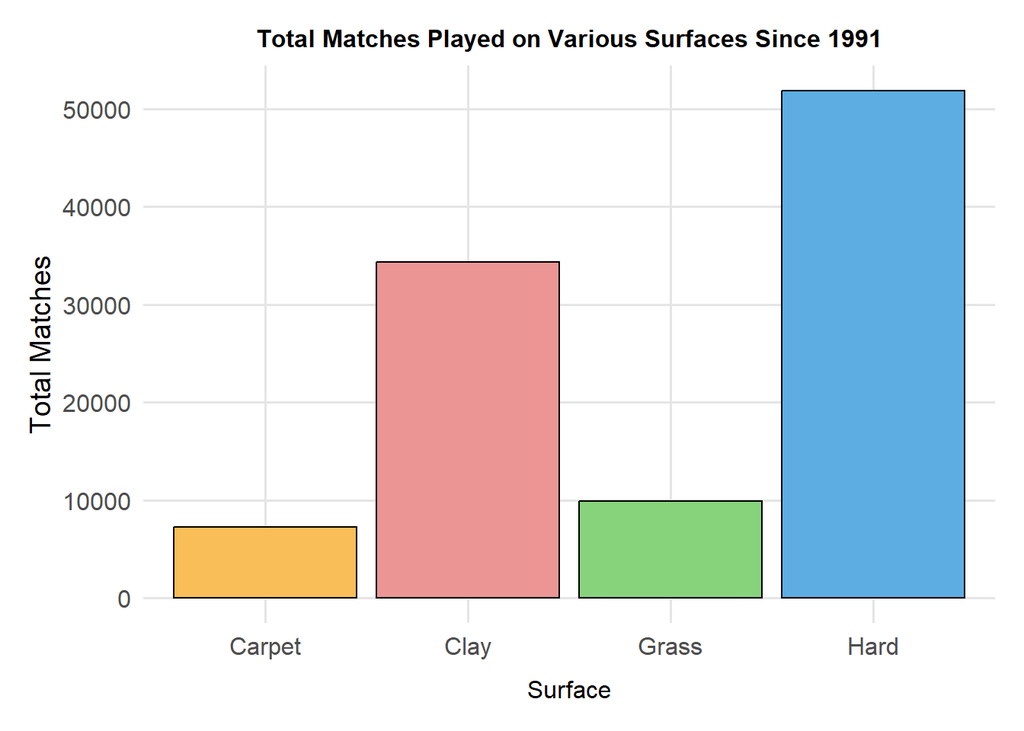

```r
# Define a custom color palette for the surfaces
surface_colors <- c("Clay" = "#EB9694",
                    "Carpet" = "#FABE58",
                    "Grass" = "#87D37C",
                    "Hard" = "#5DADE2")

# Create the bar chart with custom colors and adjusted font sizes
ggplot(data, aes(x = surface, fill = surface)) +
  geom_bar(color = "black") +
  scale_fill_manual(values = surface_colors) +
  labs(title = "Total Matches Played on Various Surfaces Since 1991",
       x = "Surface",
       y = "Total Matches") +
  theme_minimal(base_size = 14) +
  theme(legend.position = "none",
        axis.title.x = element_text(margin = margin(t = 10), size = 12),
        axis.text = element_text(size = 12),
        panel.grid.major = element_line(colour = "gray90"),
        panel.grid.minor = element_blank(),
        panel.border = element_blank(),
        plot.title = element_text(size = 12, face = "bold", hjust = 0.5),
        plot.subtitle = element_text(size = 18, hjust = 0.5, color = "gray40"),
        plot.caption = element_text(size = 14, hjust = 0, color = "gray40"),
        plot.margin = unit(c(0.5, 0.5, 0.5, 0.5), "cm"))
```

From The Histogram we can see that majority of the atp matches from 1991 are held in hard courts and the lowest are in Carpet.

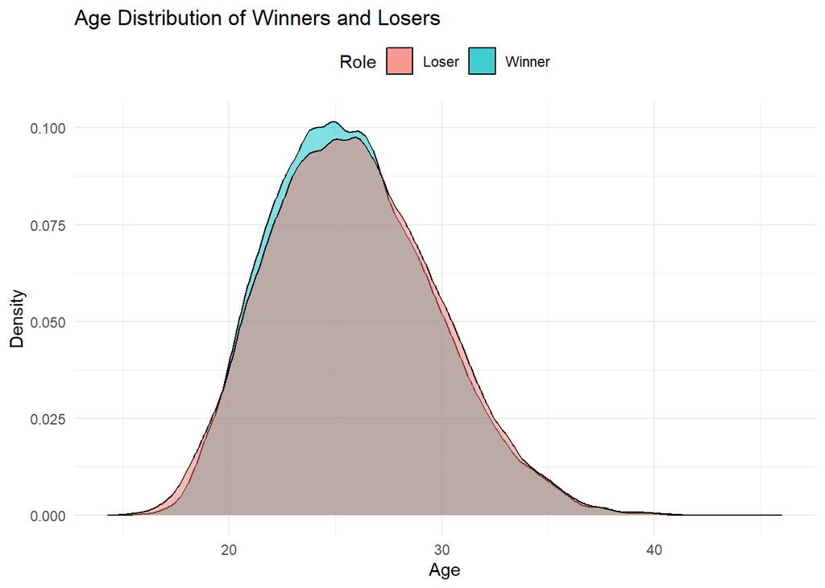

```r
# Filter out rows with missing winner_age and loser_age values
filtered_data <- data %>%
  filter(!is.na(winner_age) & !is.na(loser_age))

# Create a density plot for winner_age and loser_age
ggplot() +
  geom_density(data = filtered_data, aes(x = winner_age, fill = "Winner"), alpha = 0.5) +
  geom_density(data = filtered_data, aes(x = loser_age, fill = "Loser"), alpha = 0.5) +
  labs(x = "Age", y = "Density", title = "Age Distribution of Winners and Losers", fill = "Role") +
  theme_minimal() +
  theme(legend.position = "top")
```

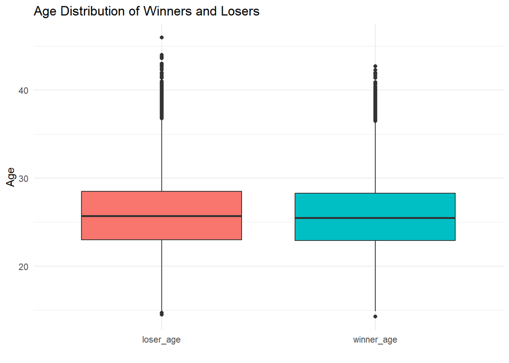

```r
# Create a box plot for winner_age and loser_age
winner_loser_age <- filtered_data %>%
  select(winner_age, loser_age) %>%
  gather(key = "Role", value = "Age", winner_age, loser_age)

ggplot(winner_loser_age, aes(x = Role, y = Age, fill = Role)) +
  geom_boxplot() +
  labs(x = "", y = "Age", title = "Age Distribution of Winners and Losers") +
  theme_minimal() +
  theme(legend.position = "none")
```

From The Density plot for Age distribution for “Losers” is wider than “Winners”, although mean value is quite the same: younger and olders players are more likely to loose matches.

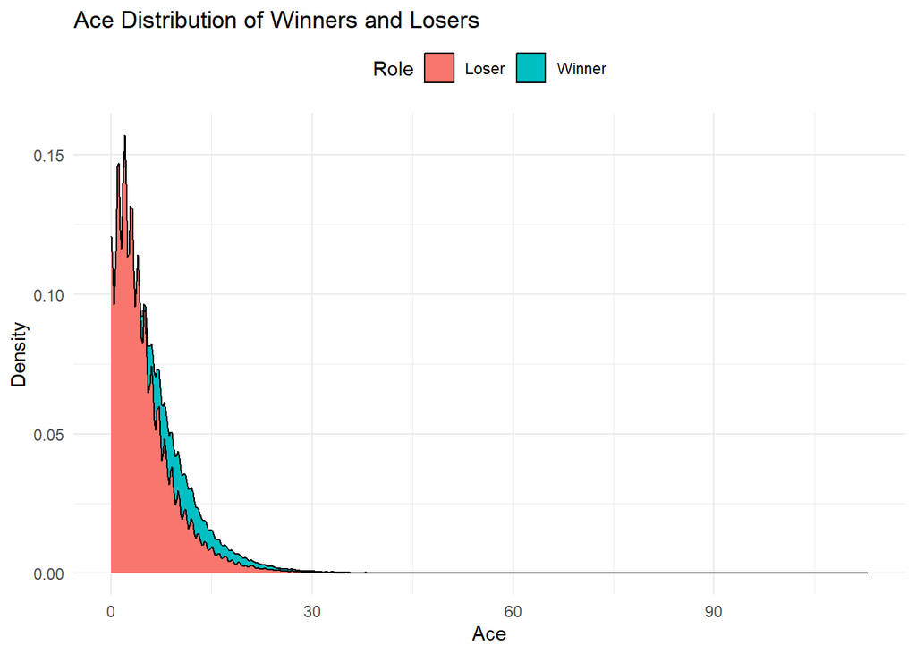

```r
# Filter out rows with missing winner_age and loser_age values
filtered_data <- data %>%
  filter(!is.na(winner_aces) & !is.na(loser_aces))

# Create a density plot for winner_ace and loser_ace
ggplot() +
  geom_density(data = filtered_data, aes(x = winner_aces, fill = "Winner")) +
  geom_density(data = filtered_data, aes(x = loser_aces, fill = "Loser")) +
  labs(x = "Ace", y = "Density", title = "Ace Distribution of Winners and Losers", fill = "Role") +
  theme_minimal() +
  theme(legend.position = "top")
```

The Density graph shows the ace distribution for winners and losers.This indicates winners having more no of aces compared to the losers which is a one of key factor in deciding the game.

```r
filtered_data <- data %>%
  mutate(winner_first_serve_pct = winner_first_serve_won / winner_first_serve_in,
         winner_second_serve_pct = winner_second_serve_won / (winner_servepointswon - winner_first_serve_in),
         loser_first_serve_pct = loser_first_serve_won / loser_first_serve_in,
         loser_second_serve_pct = loser_second_serve_won / (loser_servepointswon - loser_first_serve_in))
```

Understand the dataset with renamed columns to make more sense.

```r
xkabledplyhead(filtered_data)
```

Head

| tournament_id | tournament_name | surface | draw_size | tournament_level | tournament_date | match_num | winner_id | winner_seed | winner_entry | winner_name | winner_hand | winner_height | winner_country | winner_age | loser_id | loser_seed | loser_entry | loser_name | loser_hand | loser_height | loser_country | loser_age | score | best_of | round | minutes | winner_aces | winner_doublefaults | winner_servepointswon | … |
| --- | --- | --- | --- | --- | --- | --- | --- | --- | --- | --- | --- | --- | --- | --- | --- | --- | --- | --- | --- | --- | --- | --- | --- | --- | --- | --- | --- | --- | --- | --- |
| 1991-301 | Auckland | Hard | 32 | A | 1991-01-07 | 1 | 101142 | 1 |  | Emilio Sanchez | R | 180 | ESP | 25.6 | 101746 | NA |  | Renzo Furlan | R | 175 | ITA | 20.6 | 6-4 6-1 | 3 | R32 | 63 | 1 | 0 | 53 | … |
| 1991-301 | Auckland | Hard | 32 | A | 1991-01-07 | 2 | 101613 | NA | Q | Malivai Washington | R | 180 | USA | 21.5 | 100587 | NA | WC | Steve Guy | R | 188 | NZL | 31.8 | 6-3 6-2 | 3 | R32 | 72 | 5 | 1 | 56 | … |
| 1991-301 | Auckland | Hard | 32 | A | 1991-01-07 | 3 | 101179 | NA |  | Jean Philippe Fleurian | R | 185 | FRA | 25.3 | 101601 | NA | WC | Brett Steven | R | 185 | NZL | 21.6 | 2-6 6-1 6-2 | 3 | R32 | 101 | 2 | 4 | 80 | … |
| 1991-301 | Auckland | Hard | 32 | A | 1991-01-07 | 4 | 101117 | NA |  | Eric Jelen | R | 180 | GER | 25.8 | 101332 | 8 |  | Gilad Bloom | L | 173 | ISR | 23.8 | 6-3 1-6 6-4 | 3 | R32 | 108 | 0 | 1 | 82 | … |
| 1991-301 | Auckland | Hard | 32 | A | 1991-01-07 | 5 | 101901 | NA | Q | Chuck Adams | R | 185 | USA | 19.7 | 101735 | 3 |  | Richard Fromberg | R | 196 | AUS | 20.6 | 6-3 6-4 | 3 | R32 | 65 | 4 | 4 | 65 | … |

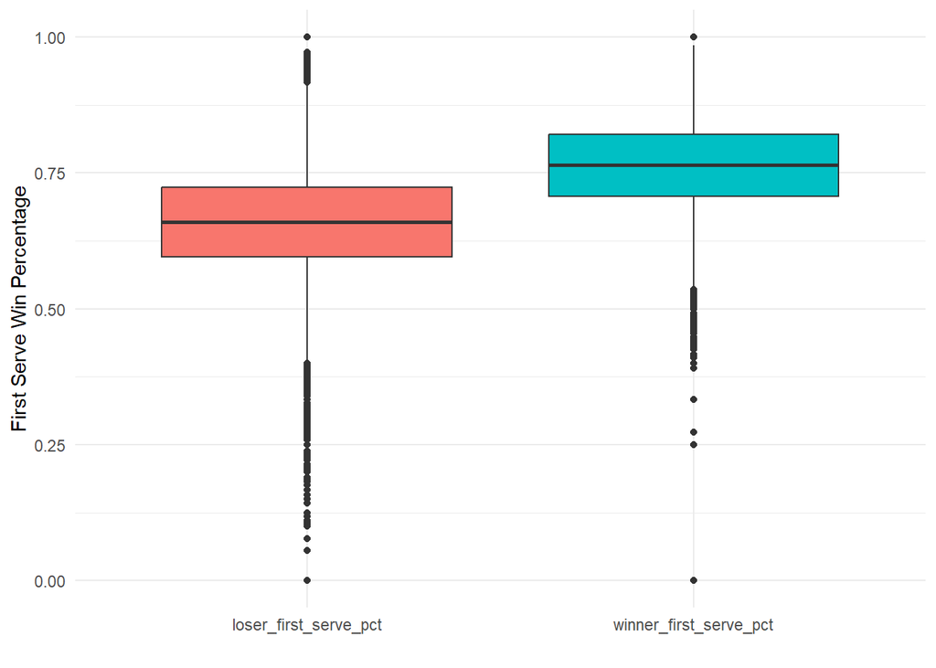

```r
# Prepare the data
winner_loser_data <- filtered_data %>%
  select(winner_first_serve_pct, loser_first_serve_pct) %>%
  gather(key = "Role", value = "First Serve Win Percentage", winner_first_serve_pct, loser_first_serve_pct)

# Create the box plot
box_plot <- ggplot(winner_loser_data, aes(x = Role, y = `First Serve Win Percentage`, fill = Role)) +
  geom_boxplot() +
  labs(x = "", y = "First Serve Win Percentage") +
  theme_minimal() +
  theme(legend.position = "none")

# Display the box plot
print(box_plot)
```

In tennis, “winner_first_serve_pct” typically refers to the percentage of first serves that a player won. It is calculated by dividing the number of first serve points won by the number of first serves that the player hit, and then multiplying by 100 to get a percentage.From the boxplot winner first serve winning percentage is quite higher than loser first serve percentage.

```r
# suffling the data randomly as it is all sorted year by year
data <- data[sample(1:nrow(data)), ]
```

```r
# Determine the number of rows in half the dataset
half_nrow <- nrow(data) %/% 2

# Split the dataset in half
first_half <- data[1:half_nrow, ]
second_half <- data[(half_nrow + 1):nrow(data), ]

# Rename columns for the first half
colnames(first_half)[grep("winner", colnames(first_half))] <- gsub("winner", "player0", colnames(first_half)[grep("winner", colnames(first_half))])
colnames(first_half)[grep("loser", colnames(first_half))] <- gsub("loser", "player1", colnames(first_half)[grep("loser", colnames(first_half))])

# Rename columns for the second half
colnames(second_half)[grep("winner", colnames(second_half))] <- gsub("winner", "player1", colnames(second_half)[grep("winner", colnames(second_half))])
colnames(second_half)[grep("loser", colnames(second_half))] <- gsub("loser", "player0", colnames(second_half)[grep("loser", colnames(second_half))])

# Add 'winner' column to the first half and set it to 0 (player0 is the winner)
first_half$winner <- 0

# Add 'winner' column to the second half and set it to 1 (player1 is the winner)
second_half$winner <- 1

# Combine the two halves
renamed_data <- rbind(first_half, second_half)
```

```r
final_data <- read_csv("tennis_data.csv", show_col_types = FALSE)
```

# Chapter 3: Model Development

We used a number of models like Logistic Regression, SVM and Random forest to predict the outcome of a tennis match.

## Features clean-up & Analysis

To predict accurately, we had to clean up the columns by merging and deleting based the correlation plot and other feature selection technique.

### Features clean-up

```r
# selects only the numeric columns from the final_data
numeric_vars <- final_data[, sapply(final_data, is.numeric)]

# computes the correlation matrix for the numeric variables
correlation_matrix <- cor(numeric_vars, use = "complete.obs")

png("heatmap_full.png", width = 800, height = 800)
corrplot(correlation_matrix, method = "color", type = "upper", order = "hclust", tl.col = "black", tl.srt = 45)
#dev.off()
```

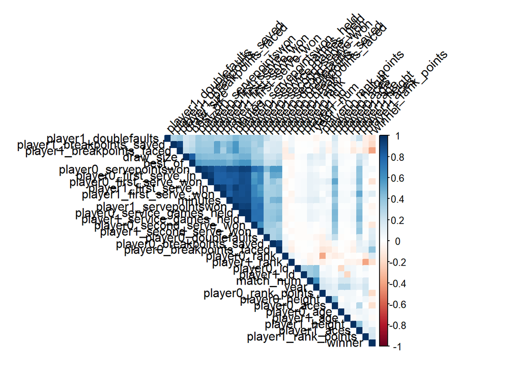

```r
corrplot(correlation_matrix, method = "color", type = "upper", order = "hclust", tl.col = "black", tl.srt = 45)
```

```r
# Keeping threshold as 0.7 for multicolinearity check
threshold <- 0.7
```

```r
correlation_matrix_no_diag <- correlation_matrix
diag(correlation_matrix_no_diag) <- 0
```

```r
highly_correlated_pairs <- which(abs(correlation_matrix_no_diag) > threshold, arr.ind = TRUE)
```

```r
highly_correlated_vars <- unique(rownames(highly_correlated_pairs))
highly_correlated_vars
```

```
##  [1] "best_of"                    "draw_size"
##  [3] "player0_servepointswon"     "player0_first_serve_in"
##  [5] "player0_first_serve_won"    "player0_second_serve_won"
##  [7] "player0_service_games_held" "player1_servepointswon"
##  [9] "player1_first_serve_in"     "player1_first_serve_won"
## [11] "player1_second_serve_won"   "player1_service_games_held"
## [13] "minutes"                    "player0_breakpoints_faced"
## [15] "player0_breakpoints_saved"  "player1_breakpoints_faced"
## [17] "player1_breakpoints_saved"
```

We have to remove some of the multicollinear variables like draw size and for other we can combine and create new variables to handle multicolinearity.

```r
# Removing fields that are not required for the analysis
tennis_data_clean <- final_data %>%
  select(-tournament_id, -tournament_name, -tournament_date, -year, -player0_seed, -player1_seed, -player0_id, -player1_id, -player0_name, -player1_name, -match_num, -score, -round, -draw_size, -player1_country, -player0_country, -player0_entry, -player1_entry, -minutes)
```

### Feature Engineering & Selection

We performed feature engineering to add new features to the dataset, reduce multicollinearity, and check the correlation of the new features. We calculated various differences and ratios to better represent the data, such as serve percentage difference, break points percentage difference, serve points won to games held difference, age difference, height difference, rank difference, and rank points difference.

```r
# Serve percentage difference
tennis_data_clean$first_serve_pct_diff <- (tennis_data_clean$player0_first_serve_won / tennis_data_clean$player0_first_serve_in) - (tennis_data_clean$player1_first_serve_won / tennis_data_clean$player1_first_serve_in)

# Break points percentage difference
tennis_data_clean$breakpoint_save_pct_diff <- with(tennis_data_clean,
    ifelse(player0_breakpoints_faced == 0, 0, player0_breakpoints_saved / player0_breakpoints_faced) -
    ifelse(player1_breakpoints_faced == 0, 0, player1_breakpoints_saved / player1_breakpoints_faced)
)

# Calculate the ratios of service points won to service games held for both players
tennis_data_clean$player0_serve_points_won_to_games_held_ratio <- ifelse(tennis_data_clean$player0_service_games_held == 0, NA, tennis_data_clean$player0_servepointswon / tennis_data_clean$player0_service_games_held)
tennis_data_clean$player1_serve_points_won_to_games_held_ratio <- ifelse(tennis_data_clean$player1_service_games_held == 0, NA, tennis_data_clean$player1_servepointswon / tennis_data_clean$player1_service_games_held)

# Calculate the difference between the two ratios
tennis_data_clean$serve_points_won_to_games_held_diff <- tennis_data_clean$player0_serve_points_won_to_games_held_ratio - tennis_data_clean$player1_serve_points_won_to_games_held_ratio

# Age difference
tennis_data_clean$age_diff <- tennis_data_clean$player0_age - tennis_data_clean$player1_age

# Height difference
tennis_data_clean$height_diff <- tennis_data_clean$player0_height - tennis_data_clean$player1_height

# Rank difference
tennis_data_clean$rank_diff <- tennis_data_clean$player0_rank - tennis_data_clean$player1_rank

# Rank points difference
tennis_data_clean$rank_points_diff <- tennis_data_clean$player0_rank_points - tennis_data_clean$player1_rank_points
```

Selected relevant features and removed the original variables that were used to create the new features.

```r
tennis_data_clean <- tennis_data_clean %>%
  select(-player0_age, -player1_age, -player0_height, -player1_height, -player0_first_serve_won, -player0_first_serve_in, -player1_first_serve_won, -player1_first_serve_in, -player0_second_serve_won, -player1_second_serve_won, -player1_rank, -player0_rank, -player0_rank_points, -player1_rank_points,
  -player0_breakpoints_faced,
  -player0_breakpoints_saved,
  -player1_breakpoints_faced,
  -player1_breakpoints_saved,
  -player0_service_games_held,
  -player1_servepointswon,
  -player1_service_games_held,
  -player0_servepointswon,
  -player1_servepointswon,
  -player1_service_games_held,
  -player0_servepointswon,
  -player0_service_games_held,
  -player1_service_games_held,
  -player0_servepointswon,
  -player0_service_games_held,
  -player1_servepointswon,
  -player0_serve_points_won_to_games_held_ratio,
  -player1_serve_points_won_to_games_held_ratio,
  )
```

```r
numeric_vars <- tennis_data_clean[, sapply(tennis_data_clean, is.numeric)]
```

```r
correlation_matrix <- cor(numeric_vars, use = "complete.obs")
```

```r
correlation_matrix_no_diag <- correlation_matrix
diag(correlation_matrix_no_diag) <- 0
highly_correlated_pairs <- which(abs(correlation_matrix_no_diag) > threshold, arr.ind = TRUE)
```

After removing some variables and feature engineering for others no highly correlated variables

```r
png("heatmap.png", width = 800, height = 800)
corrplot(correlation_matrix, method = "color", type = "upper", order = "hclust", tl.col = "black", tl.srt = 45)
#dev.off()
corrplot(correlation_matrix, method = "color", type = "upper", order = "hclust", tl.col = "black", tl.srt = 45)
```

[output not shown]

To handle missing values, replaced missing values in numeric variables with the mean and dropped rows with missing values in the player0_hand and player1_hand variables.

```r
# For all numerical variables using mean for missing values
numeric_vars <- sapply(tennis_data_clean, is.numeric)
for (col in colnames(tennis_data_clean)[numeric_vars]) {
  tennis_data_clean[[col]] <- ifelse(is.na(tennis_data_clean[[col]]), mean(tennis_data_clean[[col]], na.rm = TRUE), tennis_data_clean[[col]])
}
```

```r
# Drop rows with missing values in player0_hand or player1_hand
tennis_data_clean <- tennis_data_clean[!is.na(tennis_data_clean$player0_hand) & !is.na(tennis_data_clean$player1_hand), ]
```

Check the dataset for Nulls before modelling.

```r
# Analyze missing values in the dataset
missing_values <- tennis_data_clean %>%
  gather(variable, value) %>%
  mutate(is_missing = is.na(value)) %>%
  group_by(variable) %>%
  summarize(missing_count = sum(is_missing), total_count = n(), missing_percentage = missing_count / total_count * 100)

print(missing_values)
```

```
## # A tibble: 17 × 4
##    variable                            missing_count total_count missing_perce…¹
##    <chr>                                       <int>       <int>           <dbl>
##  1 age_diff                                        0      103191               0
##  2 best_of                                         0      103191               0
##  3 breakpoint_save_pct_diff                        0      103191               0
##  4 first_serve_pct_diff                            0      103191               0
##  5 height_diff                                     0      103191               0
##  6 player0_aces                                    0      103191               0
##  7 player0_doublefaults                            0      103191               0
##  8 player0_hand                                    0      103191               0
##  9 player1_aces                                    0      103191               0
## 10 player1_doublefaults                            0      103191               0
## 11 player1_hand                                    0      103191               0
## 12 rank_diff                                       0      103191               0
## 13 rank_points_diff                                0      103191               0
## 14 serve_points_won_to_games_held_diff             0      103191               0
## 15 surface                                         0      103191               0
## 16 tournament_level                                0      103191               0
## 17 winner                                          0      103191               0
## # … with abbreviated variable name ¹missing_percentage
```

We converted all categorical variables to factors and split the dataset into training and testing sets.

```r
# Converting all categorical variables to factors
tennis_data_clean$surface <- as.factor(tennis_data_clean$surface)
tennis_data_clean$tournament_level <- as.factor(tennis_data_clean$tournament_level)
tennis_data_clean$player0_hand <- as.factor(tennis_data_clean$player0_hand)
tennis_data_clean$player1_hand <- as.factor(tennis_data_clean$player1_hand)
```

```r
# spliting the data set into train and test
set.seed(123)
trainIndex <- createDataPartition(tennis_data_clean$winner, p = .7, list = FALSE, times = 1)
train_set <- tennis_data_clean[trainIndex, ]
test_set <- tennis_data_clean[-trainIndex, ]
```

## Modelling

### Logistic Regression

Logistic regression is a statistical modeling technique that uses predictor variables to predict the likelihood of a binary outcome variable “winner”.

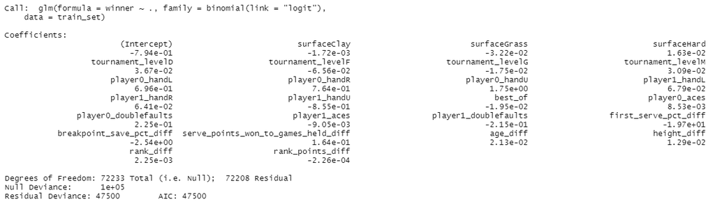

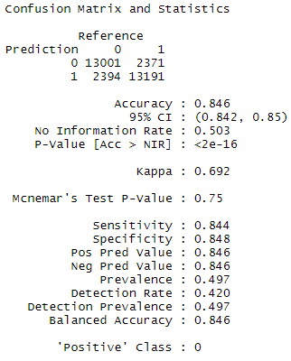

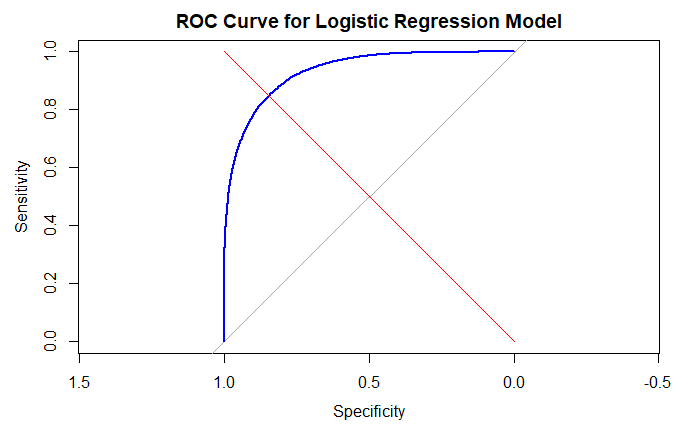

The Variance Inflation Factor is a regression analysis metric that quantifies the degree of multicollinearity between predictor variables in a model. In other words, it quantifies the extent to which the variance of the predicted regression coefficients is exaggerated due to the presence of correlated factors.

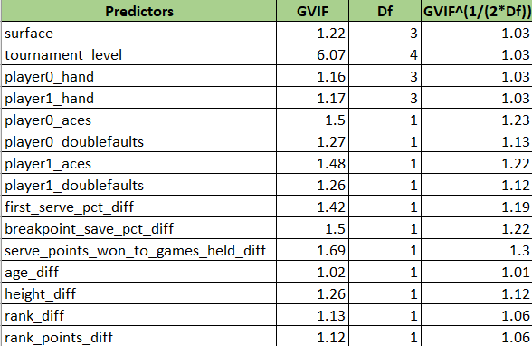

### Support Vector Machine

SVMs are a form of machine learning method that can be used for classification, regression, and outlier detection. SVM is a powerful and adaptable technique for modeling complex non-linear connections between variables.

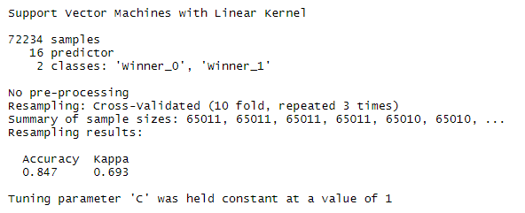

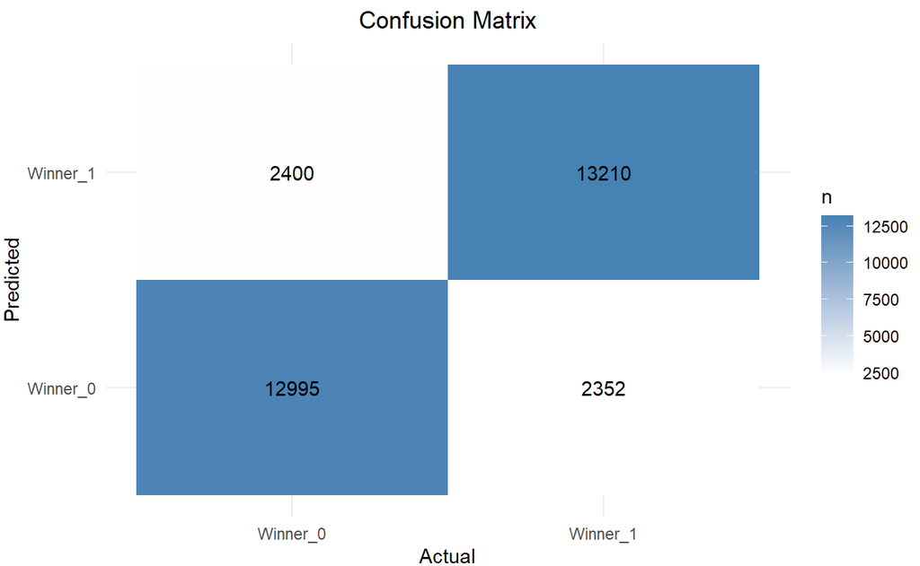

### Random Forest Model

Random forest is a machine learning technique that can be used for classification as well as regression. It is an ensemble learning method that makes predictions by combining numerous decision trees. A random subset of the training data and a random subset of the characteristics are used to build each decision tree. This adds unpredictability to the model and helps to avoid overfitting, a major issue with decision trees.

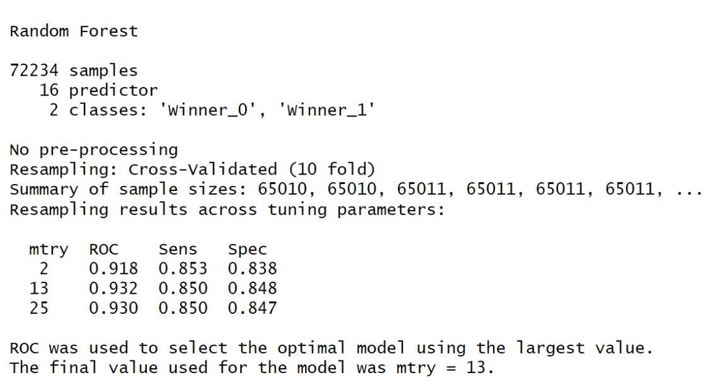

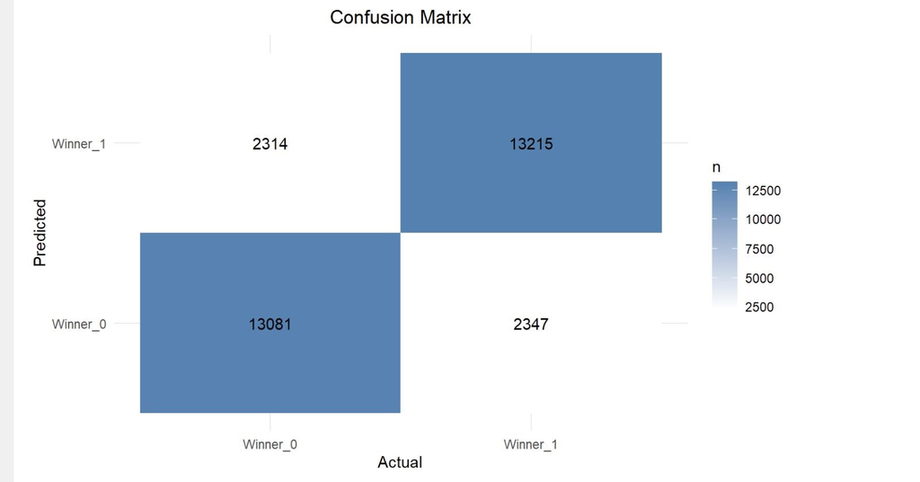

# Chapter 4: Conclusion

[figure not shown]

# Chapter 5: References

[1] B. L. Boulier and H. O. Stekler “Are sports seedings good predictors?: An evaluation,” International Journal of Forecasting, vol. 15, no. 1, pp. 83–91, feb 1999.

[2] R. A. Bradley and M. E. Terry, “Rank Analysis of Incomplete Block Designs: I. The Method of Paired Comparisons,” Biometrika, vol. 39, no. 3/4, p. 324, dec 1952.

[3] R. Praet, “Predicting Sport Results by using Recommendation Techniques,” Ph.D. dissertation, Ghent University, 2016.